# Data Visualization Report

Musaib Syed

2025-02-26

## **Introduction**

This report explores a dataset using **ggplot2** for data visualization. The dataset used in this example is `mtcars`, a built-in dataset in R that contains information about different car models.

## **Load Required Packages**

## **Load and Explore the Dataset**

```r
data(mtcars) # Load dataset
head(mtcars) # Display first few rows
```

```
##                    mpg cyl disp  hp drat    wt  qsec vs am gear carb
## Mazda RX4         21.0   6  160 110 3.90 2.620 16.46  0  1    4    4
## Mazda RX4 Wag     21.0   6  160 110 3.90 2.875 17.02  0  1    4    4
## Datsun 710        22.8   4  108  93 3.85 2.320 18.61  1  1    4    1
## Hornet 4 Drive    21.4   6  258 110 3.08 3.215 19.44  1  0    3    1
## Hornet Sportabout 18.7   8  360 175 3.15 3.440 17.02  0  0    3    2
## Valiant           18.1   6  225 105 2.76 3.460 20.22  1  0    3    1
```

### **Summary Statistics**

```r
summary(mtcars)
```

```
##       mpg             cyl             disp             hp
##  Min.   :10.40   Min.   :4.000   Min.   : 71.1   Min.   : 52.0
##  1st Qu.:15.43   1st Qu.:4.000   1st Qu.:120.8   1st Qu.: 96.5
##  Median :19.20   Median :6.000   Median :196.3   Median :123.0
##  Mean   :20.09   Mean   :6.188   Mean   :230.7   Mean   :146.7
##  3rd Qu.:22.80   3rd Qu.:8.000   3rd Qu.:326.0   3rd Qu.:180.0
##  Max.   :33.90   Max.   :8.000   Max.   :472.0   Max.   :335.0
##       drat             wt             qsec             vs
##  Min.   :2.760   Min.   :1.513   Min.   :14.50   Min.   :0.0000
##  1st Qu.:3.080   1st Qu.:2.581   1st Qu.:16.89   1st Qu.:0.0000
##  Median :3.695   Median :3.325   Median :17.71   Median :0.0000
##  Mean   :3.597   Mean   :3.217   Mean   :17.85   Mean   :0.4375
##  3rd Qu.:3.920   3rd Qu.:3.610   3rd Qu.:18.90   3rd Qu.:1.0000
##  Max.   :4.930   Max.   :5.424   Max.   :22.90   Max.   :1.0000
##        am              gear            carb
##  Min.   :0.0000   Min.   :3.000   Min.   :1.000
##  1st Qu.:0.0000   1st Qu.:3.000   1st Qu.:2.000
##  Median :0.0000   Median :4.000   Median :2.000
##  Mean   :0.4062   Mean   :3.688   Mean   :2.812
##  3rd Qu.:1.0000   3rd Qu.:4.000   3rd Qu.:4.000
##  Max.   :1.0000   Max.   :5.000   Max.   :8.000
```

The dataset contains multiple numerical variables describing various car features, such as **miles per gallon (mpg)**, **horsepower (hp)**, **weight (wt)**, and **number of cylinders (cyl)**.

## **Data Visualization: MPG vs Horsepower with Cylinder Categories**

### **Objective:**

- **Compare miles per gallon (MPG) against horsepower (HP).**
- **Color points by number of cylinders (`cyl`).**
- **Size of points represents weight (`wt`).**
- **Trend line added for better readability.**

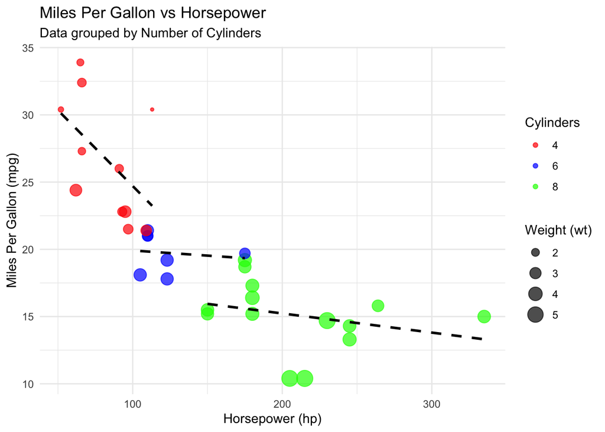

```r
ggplot(mtcars, aes(x = hp, y = mpg, color = factor(cyl))) +
  geom_point(aes(size = wt), alpha = 0.7) +  # Apply size only to points
  geom_smooth(aes(group = factor(cyl)), method = "lm", se = FALSE, linetype = "dashed", color = "black", linewidth = 1) +  # Fix group issue
  labs(
    title = "Miles Per Gallon vs Horsepower",
    subtitle = "Data grouped by Number of Cylinders",
    x = "Horsepower (hp)",
    y = "Miles Per Gallon (mpg)",
    color = "Cylinders",
    size = "Weight (wt)"
  ) +
  theme_minimal() +  # Clean theme
  scale_color_manual(values = c("red", "blue", "green"))  # Custom color scheme
```

## **Plot Explanation**

### **What the Plot Shows:**

- **MPG decreases as horsepower increases.**
- **Cars with fewer cylinders (4-cyl) tend to have higher MPG.**
- **Heavier cars (larger points) are generally less fuel-efficient.**
- **A trend line (`geom_smooth()`) confirms a negative correlation between MPG and HP.**

### **Visualization Best Practices Applied:**

✔ **Color coding** (`color=factor(cyl)`) to differentiate cylinder categories.  
✔ **Size encoding** (`size=wt`) to represent weight visually.  
✔ **Added a trend line** (`geom_smooth(method="lm")`) for clarity.  
✔ **Clear labels and title** (`labs()`).  
✔ **Minimalist theme** (`theme_minimal()`) to reduce clutter.  
✔ **Custom colors** (`scale_color_manual()`) to enhance readability.

## **Conclusion**

This visualization effectively highlights how **MPG decreases with higher horsepower** and how **cylinder count and weight** affect fuel efficiency.

To **render** this file, save it as `.Rmd` and use **Knit** in RStudio to generate an HTML report.